# 1. Exploring natality dataset

This notebook illustrates:

1. Exploring a BigQuery dataset using AI Platform Notebooks.

```python
!sudo chown -R jupyter:jupyter /home/jupyter/training-data-analyst
```

```python
# change these to try this notebook out
BUCKET = 'qwiklabs-gcp-02-68fc35316655'
PROJECT = 'qwiklabs-gcp-02-68fc35316655'
REGION = 'us-central1'
```

```python
import os
os.environ['BUCKET'] = BUCKET
os.environ['PROJECT'] = PROJECT
os.environ['REGION'] = REGION
```

```python
%%bash
if ! gsutil ls | grep -q gs://${BUCKET}/; then
  gsutil mb -l ${REGION} gs://${BUCKET}
fi
```

## Explore data

The data is natality data (record of births in the US). My goal is to predict the baby's weight given a number of factors about the pregnancy and the baby's mother. Later, we will want to split the data into training and eval datasets. The hash of the year-month will be used for that -- this way, twins born on the same day won't end up in different cuts of the data.

```python
# Create SQL query using natality data after the year 2000
query = """
SELECT
  weight_pounds,
  is_male,
  mother_age,
  plurality,
  gestation_weeks,
  FARM_FINGERPRINT(CONCAT(CAST(YEAR AS STRING), CAST(month AS STRING))) AS hashmonth
FROM
  publicdata.samples.natality
WHERE year > 2000
"""
```

```python
# Call BigQuery and examine in dataframe
from google.cloud import bigquery
df = bigquery.Client().query(query + " LIMIT 10000").to_dataframe()
df.head(10)
```

|  | weight_pounds | is_male | mother_age | plurality | gestation_weeks | hashmonth |
| --- | --- | --- | --- | --- | --- | --- |
| 0 | 7.063611 | True | 32 | 1 | 37.0 | 7108882242435606404 |
| 1 | 4.687028 | True | 30 | 3 | 33.0 | -7170969733900686954 |
| 2 | 7.561856 | True | 20 | 1 | 39.0 | 6392072535155213407 |
| 3 | 7.561856 | True | 31 | 1 | 37.0 | -2126480030009879160 |
| 4 | 7.312733 | True | 32 | 1 | 40.0 | 3408502330831153141 |
| 5 | 7.627994 | False | 30 | 1 | 40.0 | -2126480030009879160 |
| 6 | 7.251004 | True | 33 | 1 | 37.0 | 3408502330831153141 |
| 7 | 10.000168 | True | 39 | 1 | NaN | -7170969733900686954 |
| 8 | 7.500126 | False | 23 | 1 | 39.0 | 5896567601480310696 |
| 9 | 7.125340 | False | 33 | 1 | 39.0 | -7146494315947640619 |

```python
df.describe()
```

|  | weight_pounds | mother_age | plurality | gestation_weeks | hashmonth |
| --- | --- | --- | --- | --- | --- |
| count | 9997.000000 | 10000.000000 | 10000.000000 | 9886.000000 | 1.000000e+04 |
| mean | 7.303938 | 27.226500 | 1.033500 | 38.700890 | 6.055241e+17 |
| std | 1.313289 | 6.194646 | 0.192825 | 2.538734 | 5.577377e+18 |
| min | 0.595248 | 13.000000 | 1.000000 | 18.000000 | -9.183606e+18 |
| 25% | 6.624891 | 22.000000 | 1.000000 | 38.000000 | -4.979698e+18 |
| 50% | 7.374463 | 27.000000 | 1.000000 | 39.000000 | 1.088038e+18 |
| 75% | 8.126239 | 32.000000 | 1.000000 | 40.000000 | 5.934265e+18 |
| max | 12.625874 | 52.000000 | 4.000000 | 47.000000 | 8.904941e+18 |

```python
df.info()
```

```
<class 'pandas.core.frame.DataFrame'>
RangeIndex: 10000 entries, 0 to 9999
Data columns (total 6 columns):
 #   Column           Non-Null Count  Dtype
---  ------           --------------  -----
 0   weight_pounds    9997 non-null   float64
 1   is_male          10000 non-null  bool
 2   mother_age       10000 non-null  int64
 3   plurality        10000 non-null  int64
 4   gestation_weeks  9886 non-null   float64
 5   hashmonth        10000 non-null  int64
dtypes: bool(1), float64(2), int64(3)
memory usage: 400.5 KB
```

Let's write a query to find the unique values for each of the columns and the count of those values. This is important to ensure that we have enough examples of each data value, and to verify our hunch that the parameter has predictive value.

```python
df.isnull().sum()
```

```
weight_pounds        3
is_male              0
mother_age           0
plurality            0
gestation_weeks    114
hashmonth            0
dtype: int64
```

```python
df.isna()
```

|  | weight_pounds | is_male | mother_age | plurality | gestation_weeks | hashmonth |
| --- | --- | --- | --- | --- | --- | --- |
| 0 | False | False | False | False | False | False |
| 1 | False | False | False | False | False | False |
| 2 | False | False | False | False | False | False |
| 3 | False | False | False | False | False | False |
| 4 | False | False | False | False | False | False |
| ... | ... | ... | ... | ... | ... | ... |
| 9995 | False | False | False | False | False | False |
| 9996 | False | False | False | False | False | False |
| 9997 | False | False | False | False | False | False |
| 9998 | False | False | False | False | False | False |
| 9999 | False | False | False | False | False | False |

10000 rows × 6 columns

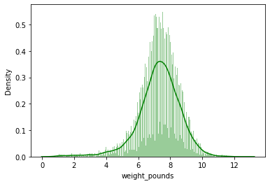

```python
import seaborn as sns

sns.distplot(df['weight_pounds'], color='g', bins=300, hist_kws={'alpha': 0.4});
```

```python
df_num = df.select_dtypes(include = ['float64', 'int64'])
df_num.head()
```

|  | weight_pounds | mother_age | plurality | gestation_weeks | hashmonth |
| --- | --- | --- | --- | --- | --- |
| 0 | 7.063611 | 32 | 1 | 37.0 | 7108882242435606404 |
| 1 | 4.687028 | 30 | 3 | 33.0 | -7170969733900686954 |
| 2 | 7.561856 | 20 | 1 | 39.0 | 6392072535155213407 |
| 3 | 7.561856 | 31 | 1 | 37.0 | -2126480030009879160 |
| 4 | 7.312733 | 32 | 1 | 40.0 | 3408502330831153141 |

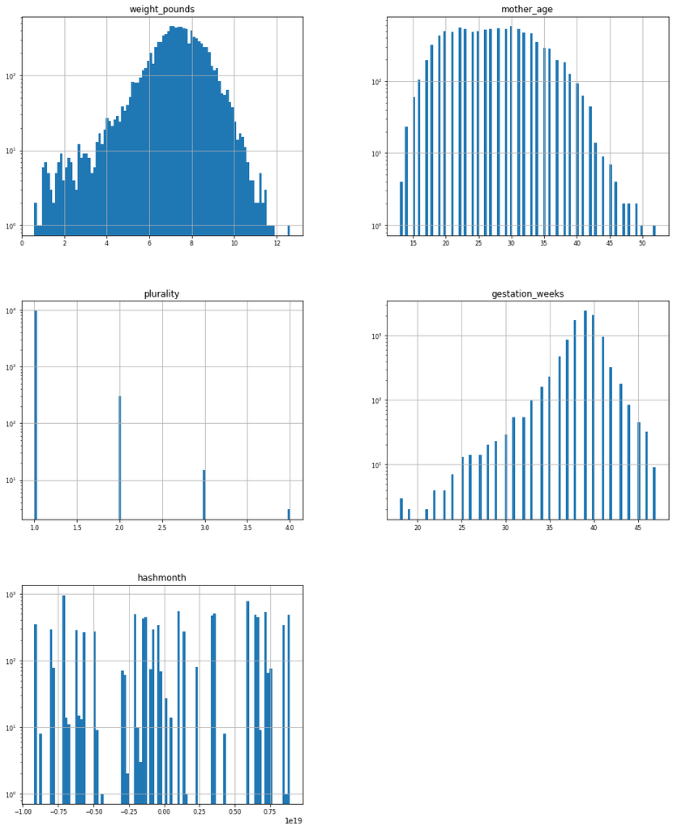

```python
df_num.hist(figsize=(16, 20), bins=100, xlabelsize=8, ylabelsize=8 , log = True); # ; avoid having the matplotlib verbose informations
```

```python
df_num_corr = df_num.corr()['weight_pounds'][:-1] # -1 because the latest row is SalePrice
golden_features_list = df_num_corr[abs(df_num_corr) > 0.0000000001].sort_values(ascending=False)
print("There is {} strongly correlated values with weight_pounds:\n{}".format(len(golden_features_list), golden_features_list))
```

```
There is 4 strongly correlated values with weight_pounds:
weight_pounds      1.000000
gestation_weeks    0.524053
mother_age         0.064437
plurality         -0.302838
Name: weight_pounds, dtype: float64
```

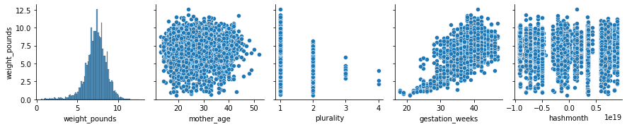

```python
import matplotlib.pyplot as plt

plt.figure(figsize =(10,10))
for i in range(0, len(df_num.columns), 5):
    sns.pairplot(data=df_num,
                x_vars=df_num.columns[i:i+5],
                y_vars=['weight_pounds'])
```

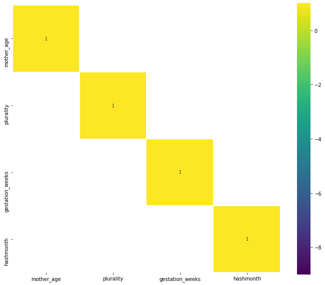

```python
corr = df_num.drop('weight_pounds', axis=1).corr() # We already examined SalePrice correlations
plt.figure(figsize=(12, 10))

sns.heatmap(corr[(corr >= 0.1) | (corr <= -0.4)],
            cmap='viridis', vmax=1.0, vmin=-9.0, linewidths=0.1,
            annot=True, annot_kws={"size": 8}, square=True);
```

```python
quantitative_features_list = [
'is_male',
'mother_age',
'plurality',
'gestation_weeks',
'hashmonth']
df_quantitative_values = df[quantitative_features_list]
df_quantitative_values.head()
```

|  | is_male | mother_age | plurality | gestation_weeks | hashmonth |
| --- | --- | --- | --- | --- | --- |
| 0 | True | 32 | 1 | 37.0 | 7108882242435606404 |
| 1 | True | 30 | 3 | 33.0 | -7170969733900686954 |
| 2 | True | 20 | 1 | 39.0 | 6392072535155213407 |
| 3 | True | 31 | 1 | 37.0 | -2126480030009879160 |
| 4 | True | 32 | 1 | 40.0 | 3408502330831153141 |

```python
features_to_analyse = [x for x in quantitative_features_list if x in golden_features_list]
features_to_analyse.append('weight_pounds')
features_to_analyse
```

```
['mother_age', 'plurality', 'gestation_weeks', 'weight_pounds']
```

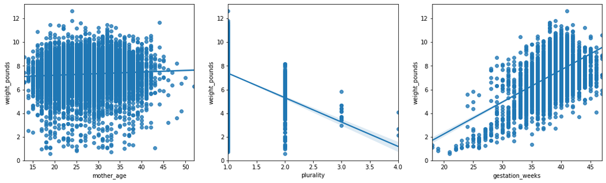

```python
fig, ax = plt.subplots(round(len(features_to_analyse) / 3), 3, figsize = (18, 5))

for i, ax in enumerate(fig.axes):
    if i < len(features_to_analyse) - 1:
        sns.regplot(x=features_to_analyse[i],y='weight_pounds', data=df[features_to_analyse], ax=ax)
```

```python
categorical_features = ['is_male' , 'weight_pounds']
df_categ = df[categorical_features]
df_categ.head()
```

|  | is_male | weight_pounds |
| --- | --- | --- |
| 0 | True | 7.063611 |
| 1 | True | 4.687028 |
| 2 | True | 7.561856 |
| 3 | True | 7.561856 |
| 4 | True | 7.312733 |

```
(array([0, 1]), [Text(0, 0, 'False'), Text(1, 0, 'True')])
```

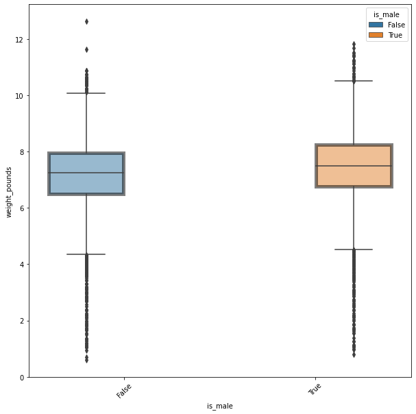

```python
plt.figure(figsize = (10, 10))
ax = sns.boxplot(x='is_male', y='weight_pounds', data=df_categ, hue="is_male")
plt.setp(ax.artists, alpha=.5, linewidth=5, edgecolor="k")
plt.xticks(rotation=45)
```

```python
# Create function that finds the number of records and the average weight for each value of the chosen column
def get_distinct_values(column_name):
  sql = """
SELECT
  {0},
  COUNT(1) AS num_babies,
  AVG(weight_pounds) AS avg_wt
FROM
  publicdata.samples.natality
WHERE
  year > 2000
GROUP BY
  {0}
  """.format(column_name)
  return bigquery.Client().query(sql).to_dataframe()
```

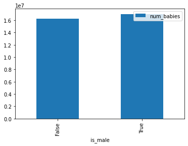

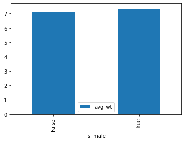

```python
# Bar plot to see is_male with avg_wt linear and num_babies logarithmic
df = get_distinct_values('is_male')
df.plot(x='is_male', y='num_babies', kind='bar');
df.plot(x='is_male', y='avg_wt', kind='bar');
```

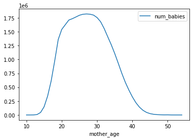

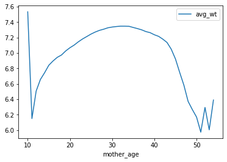

```python
# Line plots to see mother_age with avg_wt linear and num_babies logarithmic
df = get_distinct_values('mother_age')
df = df.sort_values('mother_age')
df.plot(x='mother_age', y='num_babies');
df.plot(x='mother_age', y='avg_wt');
```

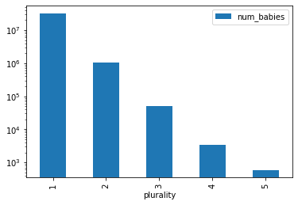

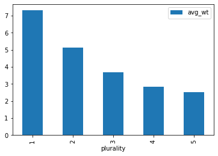

```python
# Bar plot to see plurality(singleton, twins, etc.) with avg_wt linear and num_babies logarithmic
df = get_distinct_values('plurality')
df = df.sort_values('plurality')
df.plot(x='plurality', y='num_babies', logy=True, kind='bar');
df.plot(x='plurality', y='avg_wt', kind='bar');
```

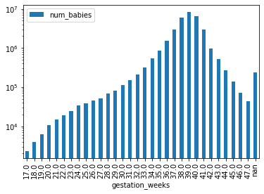

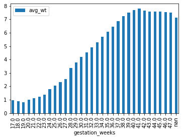

```python
# Bar plot to see gestation_weeks with avg_wt linear and num_babies logarithmic
df = get_distinct_values('gestation_weeks')
df = df.sort_values('gestation_weeks')
df.plot(x='gestation_weeks', y='num_babies', logy=True, kind='bar');
df.plot(x='gestation_weeks', y='avg_wt', kind='bar');
```

In the next notebook, I will develop a machine learning model to combine all of these factors to come up with a prediction of a baby's weight.

Copyright 2017-2018 Google Inc. Licensed under the Apache License, Version 2.0 (the "License"); you may not use this file except in compliance with the License. You may obtain a copy of the License at http://www.apache.org/licenses/LICENSE-2.0 Unless required by applicable law or agreed to in writing, software distributed under the License is distributed on an "AS IS" BASIS, WITHOUT WARRANTIES OR CONDITIONS OF ANY KIND, either express or implied. See the License for the specific language governing permissions and limitations under the License